# Découverte du jeu de données du projet SIWIM

# Feature engineering

Nous allons dans cette section partir des données brutes afin de les retravailler en recodant certaines variables

```r
# chargement des librairies

library(data.table)
library(stringr) # manipulation de chaine de caracteres
library(missMDA) # imputation des données manquantes
library(questionr) # calcul Vcramer et des fréquences
library(ggplot2)
```

```r
# Chargement des données brutes, récupérées par scraping et reformatées
siwim_data <- fread("2_Data/2_Retraitees/SiWIM_data_formated.csv")
```

```
##
Read 21.7% of 183928 rows
Read 70.7% of 183928 rows
Read 183928 rows and 47 (of 47) columns from 0.042 GB file in 00:00:04
```

Nous recodons / renommons certaines variables qualitatives :

```r
# Suppression de variables inutiles
siwim_data[, c("Stage_trace", "Offset", "Impact_factor") := NULL]

# Conversion en factor de la variable Site_ID
siwim_data[, Site_ID := as.factor(Site_ID)]

# Conversion en factor de la variable Warning_flags
siwim_data[, Warning_flags := as.factor(Warning_flags)]

# Recodification de la variable lane (0 = droite, 1 = gauche)
siwim_data[, Lane := factor(siwim_data$Lane, labels = c("droite", "gauche"))]

# Conversion en factor de la variable Subclass_ID
siwim_data[, Subclass_ID := factor(siwim_data$Subclass_ID)]

# Conversion en factor de la variable Axle_groups
siwim_data[, Axle_groups := factor(siwim_data$Axle_groups)]

# Renommage et conversion en factor de la variable N (nombre d'axes)
siwim_data[, Nb_axles := factor(siwim_data$N)]
```

De nouvelles variables de date sont créées à partir de la variable `timestamp`:

```r
# Creation de variables depuis timestamp au format POSIXct :
siwim_data[, Date    := as.POSIXct(substr(siwim_data$Timestamp,1,10), format = '%Y-%m-%d')]
siwim_data[, Horaire := substr(siwim_data$Timestamp,12,19)]
siwim_data[, Timestamp := as.POSIXct(substr(siwim_data$Timestamp,1,19), format = '%Y-%m-%d %H:%M:%S')]

# Création d'une variable temporelle quantitative depuis le 1er Janvier 2017

siwim_data[, Time_num := as.numeric((siwim_data$Timestamp - as.POSIXct("2017-01-01 00:00:00", format = '%Y-%m-%d %H:%M:%S'))/360)]

# Creation de variables temporelles de type factor
siwim_data[, Annee := as.factor(strftime(siwim_data$Date, format = "%Y"))]
siwim_data[, Mois_num := as.factor(strftime(siwim_data$Date, format = "%m"))]
siwim_data[, Mois_annee := as.factor(strftime(siwim_data$Date, format = "%B"))]
siwim_data[, Jour_num := as.factor(strftime(siwim_data$Date, format = "%d"))]
siwim_data[, Jour_semaine := as.factor(strftime(siwim_data$Date, format = "%A"))]
siwim_data[, Heure := as.factor(str_sub(Horaire, 1, 2))]
```

Creation de la variable qualitative `Anomalie` :

```r
siwim_data[,Anomalie := "N"][Warning_flags != "00000000",Anomalie := "Y"]

# Transformation en factor
siwim_data[, Anomalie := factor(siwim_data$Anomalie)]
```

Plusieurs variables ont des unités anglo-saxonnes, nous les recalculons dans des unités européennes :

```r
# Passage de la vitesse en km/h
siwim_data[, Vitesse := siwim_data$v * (36/10)]

# Passage du poids en tonnes
siwim_data[, MGV := siwim_data$WGV / 9.81]

# Passage du poids de chaque essieu en tonnes
maxN <- 16
axles_load <- paste("W", 1:maxN, sep = "")
axles_mass <- paste("M", 1:maxN, sep = "")
axles_load
```

```
##  [1] "W1"  "W2"  "W3"  "W4"  "W5"  "W6"  "W7"  "W8"  "W9"  "W10" "W11"
## [12] "W12" "W13" "W14" "W15" "W16"
```

```r
siwim_data[, (axles_mass) := lapply(axles_load, function(x){get(x)/9.81})]
```

Certaines variables désormais inutiles sont retirées :

```r
# Suppression de la variable index V1 avant écriture des données dans le .csv
siwim_data[, V1 := NULL]

# Suppression des variables d'origine codées dans des unités anglo-saxonnes
siwim_data [, c("v","WGV", "W1","W2","W3","W4","W5","W6","W7","W8","W9","W10",
         "W11","W12","W13","W14","W15","W16") := NULL]
```

# Résumés et valeur manquantes

Le jeu de données contient 54 variables et environ 184 000 lignes :

```r
dim(siwim_data)
```

```
## [1] 183928     54
```

Chaque ligne représente les valeurs des variables pour un camion capturé par le système de pesage par poids du Pont de Normandie.

Il est important de rappeler que le système comporte sa propre fiabilité et est possiblement amené à capturer du bruit ou à dysfonctionner.

Nous notons ici la présence de nombreuses valeur manquantes ou de valeur aberrantes lorsque nous analysons par exemple les minimum ou les maximum de certaines variables.

```r
summary(siwim_data)
```

```
##    Timestamp                        Site_ID        Warning_flags
##  Min.   :2017-07-05 00:08:33   Normandie:183928   00000000:130647
##  1st Qu.:2017-08-02 11:36:19                      00008000: 10159
##  Median :2017-09-06 17:12:22                      00800000: 10033
##  Mean   :2017-09-12 14:28:02                      00000001: 10018
##  3rd Qu.:2017-10-25 21:47:16                      00000080:  9102
##  Max.   :2017-11-23 18:59:49                      00000081:  4572
##                                                   (Other) :  9397
##      Lane              N           Subclass_ID     Axle_groups
##  droite:167810   Min.   : 2.000   113    :72716   113    :94326
##  gauche: 16118   1st Qu.: 4.000   61     :19835   11     :31004
##                  Median : 5.000   74     :15576   112    :24591
##                  Mean   : 4.357   40     :11317   111    : 5368
##                  3rd Qu.: 5.000   140    :10661   12     : 4826
##                  Max.   :16.000   41     : 9320   (Other):23804
##                                   (Other):44503   NA's   :    9
##  total_axle_dist         A1                A2              A3
##  Min.   : 0.9032   Min.   : 0.3191   Min.   : 0.33   Min.   : 0.35
##  1st Qu.: 9.2666   1st Qu.: 3.7209   1st Qu.: 5.05   1st Qu.: 1.32
##  Median :12.1818   Median : 3.8425   Median : 5.78   Median : 1.35
##  Mean   :11.2357   Mean   : 4.0128   Mean   : 5.34   Mean   : 1.76
##  3rd Qu.:12.4545   3rd Qu.: 3.9704   3rd Qu.: 6.03   3rd Qu.: 1.41
##  Max.   :80.8727   Max.   :19.8194   Max.   :18.88   Max.   :19.50
##                                      NA's   :32323   NA's   :43346
##        A4              A5               A6               A7
##  Min.   : 0.33   Min.   : 0.32    Min.   : 0.44    Min.   : 0.33
##  1st Qu.: 1.30   1st Qu.: 1.34    1st Qu.: 1.35    1st Qu.: 1.39
##  Median : 1.34   Median : 1.92    Median : 1.72    Median : 2.77
##  Mean   : 1.55   Mean   : 3.29    Mean   : 3.16    Mean   : 3.59
##  3rd Qu.: 1.38   3rd Qu.: 4.72    3rd Qu.: 4.59    3rd Qu.: 5.45
##  Max.   :17.44   Max.   :19.82    Max.   :17.30    Max.   :18.64
##  NA's   :71942   NA's   :174408   NA's   :178322   NA's   :180303
##        A8               A9              A10              A11
##  Min.   : 0.48    Min.   : 0.51    Min.   : 0.41    Min.   : 0.70
##  1st Qu.: 1.37    1st Qu.: 1.36    1st Qu.: 1.37    1st Qu.: 1.36
##  Median : 2.60    Median : 2.33    Median : 2.30    Median : 2.04
##  Mean   : 3.48    Mean   : 3.41    Mean   : 3.42    Mean   : 3.36
##  3rd Qu.: 5.20    3rd Qu.: 5.12    3rd Qu.: 5.15    3rd Qu.: 5.01
##  Max.   :16.70    Max.   :17.71    Max.   :17.39    Max.   :15.26
##  NA's   :181085   NA's   :181681   NA's   :182166   NA's   :182570
```

[output cut: 65 more lines]

```
##  Min.   :0.00     Min.   :0.00     Min.   :0.00     Min.   :0.00
##  1st Qu.:0.00     1st Qu.:0.00     1st Qu.:0.00     1st Qu.:0.00
##  Median :0.00     Median :0.00     Median :0.00     Median :0.00
##  Mean   :0.10     Mean   :0.09     Mean   :0.09     Mean   :0.09
##  3rd Qu.:0.00     3rd Qu.:0.00     3rd Qu.:0.00     3rd Qu.:0.00
##  Max.   :8.18     Max.   :5.17     Max.   :6.48     Max.   :4.81
##  NA's   :182570   NA's   :182917   NA's   :183230   NA's   :183476
##       M16
##  Min.   :0.00
##  1st Qu.:0.00
##  Median :0.00
##  Mean   :0.11
##  3rd Qu.:0.00
##  Max.   :5.71
##  NA's   :183725
```

Nous allons créer deux dataframe :

- `varquali` contiendra les variables qualitatives
- `varquanti` contiendra les variables quantitatives

```r
varquanti <- siwim_data[, lapply(siwim_data, is.numeric) == TRUE, with = FALSE]
varquali <- siwim_data[,lapply(siwim_data,is.numeric) == FALSE, with = FALSE]
```

Regardons à présent le résumé concernant les variables quantitatives :

```r
summary(varquanti)
```

```
##        N          total_axle_dist         A1                A2
##  Min.   : 2.000   Min.   : 0.9032   Min.   : 0.3191   Min.   : 0.33
##  1st Qu.: 4.000   1st Qu.: 9.2666   1st Qu.: 3.7209   1st Qu.: 5.05
##  Median : 5.000   Median :12.1818   Median : 3.8425   Median : 5.78
##  Mean   : 4.357   Mean   :11.2357   Mean   : 4.0128   Mean   : 5.34
##  3rd Qu.: 5.000   3rd Qu.:12.4545   3rd Qu.: 3.9704   3rd Qu.: 6.03
##  Max.   :16.000   Max.   :80.8727   Max.   :19.8194   Max.   :18.88
##                                                       NA's   :32323
##        A3              A4              A5               A6
##  Min.   : 0.35   Min.   : 0.33   Min.   : 0.32    Min.   : 0.44
##  1st Qu.: 1.32   1st Qu.: 1.30   1st Qu.: 1.34    1st Qu.: 1.35
##  Median : 1.35   Median : 1.34   Median : 1.92    Median : 1.72
##  Mean   : 1.76   Mean   : 1.55   Mean   : 3.29    Mean   : 3.16
##  3rd Qu.: 1.41   3rd Qu.: 1.38   3rd Qu.: 4.72    3rd Qu.: 4.59
##  Max.   :19.50   Max.   :17.44   Max.   :19.82    Max.   :17.30
##  NA's   :43346   NA's   :71942   NA's   :174408   NA's   :178322
##        A7               A8               A9              A10
##  Min.   : 0.33    Min.   : 0.48    Min.   : 0.51    Min.   : 0.41
##  1st Qu.: 1.39    1st Qu.: 1.37    1st Qu.: 1.36    1st Qu.: 1.37
##  Median : 2.77    Median : 2.60    Median : 2.33    Median : 2.30
##  Mean   : 3.59    Mean   : 3.48    Mean   : 3.41    Mean   : 3.42
##  3rd Qu.: 5.45    3rd Qu.: 5.20    3rd Qu.: 5.12    3rd Qu.: 5.15
##  Max.   :18.64    Max.   :16.70    Max.   :17.71    Max.   :17.39
##  NA's   :180303   NA's   :181085   NA's   :181681   NA's   :182166
##       A11              A12              A13              A14
##  Min.   : 0.70    Min.   : 0.79    Min.   : 0.91    Min.   : 0.90
##  1st Qu.: 1.36    1st Qu.: 1.39    1st Qu.: 1.36    1st Qu.: 1.39
##  Median : 2.04    Median : 2.20    Median : 1.97    Median : 1.92
##  Mean   : 3.36    Mean   : 3.47    Mean   : 3.22    Mean   : 3.22
##  3rd Qu.: 5.01    3rd Qu.: 5.24    3rd Qu.: 4.42    3rd Qu.: 4.22
##  Max.   :15.26    Max.   :15.51    Max.   :10.90    Max.   :10.93
##  NA's   :182570   NA's   :182917   NA's   :183230   NA's   :183476
##       A15               T           Reduced_chi_squared    Time_num
##  Min.   : 0.98    Min.   :-273.00   Min.   :    0.0     Min.   :0.5138
##  1st Qu.: 1.37    1st Qu.:  13.52   1st Qu.:  100.0     1st Qu.:0.5929
##  Median : 2.06    Median :  17.69   Median :  250.6     Median :0.6908
##  Mean   : 3.38    Mean   :  15.95   Mean   :  475.5     Mean   :0.7071
##  3rd Qu.: 4.96    3rd Qu.:  23.40   3rd Qu.:  524.5     3rd Qu.:0.8274
##  Max.   :10.98    Max.   :  47.57   Max.   :29201.3     Max.   :0.9078
##  NA's   :183725
```

[output cut: 25 more lines]

```
##  Min.   : 0.00    Min.   :0.00     Min.   :0.00     Min.   :0.00
##  1st Qu.: 0.00    1st Qu.:0.00     1st Qu.:0.00     1st Qu.:0.00
##  Median : 0.00    Median :0.00     Median :0.00     Median :0.00
##  Mean   : 0.14    Mean   :0.10     Mean   :0.09     Mean   :0.09
##  3rd Qu.: 0.00    3rd Qu.:0.00     3rd Qu.:0.00     3rd Qu.:0.00
##  Max.   :13.70    Max.   :8.18     Max.   :5.17     Max.   :6.48
##  NA's   :182166   NA's   :182570   NA's   :182917   NA's   :183230
##       M15              M16
##  Min.   :0.00     Min.   :0.00
##  1st Qu.:0.00     1st Qu.:0.00
##  Median :0.00     Median :0.00
##  Mean   :0.09     Mean   :0.11
##  3rd Qu.:0.00     3rd Qu.:0.00
##  Max.   :4.81     Max.   :5.71
##  NA's   :183476   NA's   :183725
```

Même raisonnement pour la masse sur chaque essieu où 16 variables `Mi` sont présentes dans le jeu de données et comportent des valeurs manquantes.

Le nombre de valeurs manquantes n’étant pas négligeable, il faudra les traiter comme nous le verrons ci-après.

```r
summary(varquali)
```

```
##    Timestamp                        Site_ID        Warning_flags
##  Min.   :2017-07-05 00:08:33   Normandie:183928   00000000:130647
##  1st Qu.:2017-08-02 11:36:19                      00008000: 10159
##  Median :2017-09-06 17:12:22                      00800000: 10033
##  Mean   :2017-09-12 14:28:02                      00000001: 10018
##  3rd Qu.:2017-10-25 21:47:16                      00000080:  9102
##  Max.   :2017-11-23 18:59:49                      00000081:  4572
##                                                   (Other) :  9397
##      Lane         Subclass_ID     Axle_groups       Nb_axles
##  droite:167810   113    :72716   113    :94326   5      :102466
##  gauche: 16118   61     :19835   11     :31004   2      : 32323
##                  74     :15576   112    :24591   4      : 28596
##                  40     :11317   111    : 5368   3      : 11023
##                  140    :10661   12     : 4826   6      :  3914
##                  41     : 9320   (Other):23804   7      :  1981
##                  (Other):44503   NA's   :    9   (Other):  3625
##       Date                       Horaire           Annee        Mois_num
##  Min.   :2017-07-05 00:00:00   Length:183928      2017:183928   07:42860
##  1st Qu.:2017-08-02 00:00:00   Class :character                 08:40498
##  Median :2017-09-06 00:00:00   Mode  :character                 09:32125
##  Mean   :2017-09-12 01:53:14                                    10:32006
##  3rd Qu.:2017-10-25 00:00:00                                    11:36439
##  Max.   :2017-11-23 00:00:00
##
##      Mois_annee       Jour_num        Jour_semaine       Heure
##  août     :40498   21     :  8674   dimanche: 3432   15     : 14555
##  juillet  :42860   07     :  8448   jeudi   :38343   14     : 14432
##  novembre :36439   20     :  7996   lundi   :32477   10     : 13402
##  octobre  :32006   17     :  7353   mardi   :35025   09     : 13172
##  septembre:32125   26     :  7125   mercredi:39287   16     : 13096
##                    06     :  6994   samedi  : 5359   13     : 13069
##                    (Other):137338   vendredi:30005   (Other):102202
##  Anomalie
##  N:130647
##  Y: 53281
##
##
##
##
##
```

Pour les variables qualitatives, seule la variable `Axles_groups` comportent des valeurs manquantes (9)

En résumé : la qualité du jeu de donnée est bonne du point de vue des valeurs manquantes.

# Analyse unidimensionnelle des variables qualitatives

Nous analysons les fréquences des modalités de chaque variable qualitative.

```r
# Mois de circulation
freq(varquali[,.(Mois_annee)], cum = TRUE, total = TRUE, sort = "dec")
```

|  | n | % | val% | %cum | val%cum |
| --- | --- | --- | --- | --- | --- |
| juillet | 42860 | 23.3 | 23.3 | 23.3 | 23.3 |
| août | 40498 | 22.0 | 22.0 | 45.3 | 45.3 |
| novembre | 36439 | 19.8 | 19.8 | 65.1 | 65.1 |
| septembre | 32125 | 17.5 | 17.5 | 82.6 | 82.6 |
| octobre | 32006 | 17.4 | 17.4 | 100.0 | 100.0 |
| NA | 0 | 0.0 | NA | 100.0 | NA |
| Total | 183928 | 100.0 | 100.0 | 100.0 | 100.0 |

Nous remarquons que les données ici représentées le sont sur un espace de temps limité. On note un léger pic de circulation l’Eté.

```r
# jour de circulation
freq(varquali[,.(Jour_semaine)], cum = TRUE, total = TRUE, sort = "dec")
```

|  | n | % | val% | %cum | val%cum |
| --- | --- | --- | --- | --- | --- |
| mercredi | 39287 | 21.4 | 21.4 | 21.4 | 21.4 |
| jeudi | 38343 | 20.8 | 20.8 | 42.2 | 42.2 |
| mardi | 35025 | 19.0 | 19.0 | 61.2 | 61.2 |
| lundi | 32477 | 17.7 | 17.7 | 78.9 | 78.9 |
| vendredi | 30005 | 16.3 | 16.3 | 95.2 | 95.2 |
| samedi | 5359 | 2.9 | 2.9 | 98.1 | 98.1 |
| dimanche | 3432 | 1.9 | 1.9 | 100.0 | 100.0 |
| NA | 0 | 0.0 | NA | 100.0 | NA |
| Total | 183928 | 100.0 | 100.0 | 100.0 | 100.0 |

Les jours de la semaines sont les plus circulés par les poids lourds. Les moins circulés sont le week-end, ce qui est assez net.

Pour rappel En France, à l’exclusion des véhicules spécialisés et des matériels et engins agricoles, les camions n’ont pas le droit de circuler du samedi 22 heures au dimanche 22 heures. Cette interdiction générale s’applique également les veilles de jours fériés à partir de 22 heures jusqu’à 22 heures le lendemain.

```r
# heure de circulation
freq(varquali[,.(Heure)], cum = TRUE, total = TRUE, sort = "dec")
```

|  | n | % | val% | %cum | val%cum |
| --- | --- | --- | --- | --- | --- |
| 15 | 14555 | 7.9 | 7.9 | 7.9 | 7.9 |
| 14 | 14432 | 7.8 | 7.8 | 15.8 | 15.8 |
| 10 | 13402 | 7.3 | 7.3 | 23.0 | 23.0 |
| 09 | 13172 | 7.2 | 7.2 | 30.2 | 30.2 |
| 16 | 13096 | 7.1 | 7.1 | 37.3 | 37.3 |
| 13 | 13069 | 7.1 | 7.1 | 44.4 | 44.4 |
| 07 | 12753 | 6.9 | 6.9 | 51.4 | 51.4 |
| 08 | 12677 | 6.9 | 6.9 | 58.3 | 58.3 |
| 11 | 12647 | 6.9 | 6.9 | 65.1 | 65.1 |
| 12 | 12551 | 6.8 | 6.8 | 72.0 | 72.0 |

[output cut: 16 more lines]

Les camions semblent moins circuler de 20h à 5h (donc la nuit) qu’en journée. En effet, environ 90 % des passages ont lieu entre 6h et 19h.

```r
# voie
freq(varquali[,.(Lane)], cum = TRUE, total = TRUE, sort = "dec")
```

|  | n | % | val% | %cum | val%cum |
| --- | --- | --- | --- | --- | --- |
| droite | 167810 | 91.2 | 91.2 | 91.2 | 91.2 |
| gauche | 16118 | 8.8 | 8.8 | 100.0 | 100.0 |
| NA | 0 | 0.0 | NA | 100.0 | NA |
| Total | 183928 | 100.0 | 100.0 | 100.0 | 100.0 |

Lors de la capture des données 91% des camions ont roulé à droite. Les 9% ayant roulé à gauche réalisaient-ils un dépassement ?

```r
freq(varquali[,.(Anomalie)], cum = TRUE, total = TRUE, sort = "dec")
```

|  | n | % | val% | %cum | val%cum |
| --- | --- | --- | --- | --- | --- |
| N | 130647 | 71 | 71 | 71 | 71 |
| Y | 53281 | 29 | 29 | 100 | 100 |
| NA | 0 | 0 | NA | 100 | NA |
| Total | 183928 | 100 | 100 | 100 | 100 |

29 % des passages ont été taggé en anomalie.

Analysons le détail, en excluant la modalité `00000000` signifiant qu’il n’y a pas d’anomalie :

```r
freq(varquali[,.(Warning_flags)], exclude = c("00000000"), cum = TRUE, total = TRUE, sort = "dec")
```

|  | n | % | val% | %cum | val%cum |
| --- | --- | --- | --- | --- | --- |
| 00008000 | 10159 | 19.1 | 19.1 | 19.1 | 19.1 |
| 00800000 | 10033 | 18.8 | 18.8 | 37.9 | 37.9 |
| 00000001 | 10018 | 18.8 | 18.8 | 56.7 | 56.7 |
| 00000080 | 9102 | 17.1 | 17.1 | 73.8 | 73.8 |
| 00000081 | 4572 | 8.6 | 8.6 | 82.4 | 82.4 |
| 00000200 | 4460 | 8.4 | 8.4 | 90.7 | 90.7 |
| 00000800 | 984 | 1.8 | 1.8 | 92.6 | 92.6 |
| 00800001 | 950 | 1.8 | 1.8 | 94.4 | 94.4 |
| 00000201 | 719 | 1.3 | 1.3 | 95.7 | 95.7 |
| 00008001 | 653 | 1.2 | 1.2 | 96.9 | 96.9 |

[output cut: 22 more lines]

Les anomalies les plus fréquentes sont donc :

- `00008000` : vehicle reconstructed
- `00800000` : vehicle overloaded
- `00000001` : multiple truck presence
- `00000080` : negative axle loads or WGV
- `00000081` : ?
- `00000200` : vehicle reclassified

```r
# Subclass_ID : classification réalisée par le système de pesage
freq(varquali[,.(Subclass_ID)], cum = TRUE, total = TRUE, sort = "dec")
```

|  | n | % | val% | %cum | val%cum |
| --- | --- | --- | --- | --- | --- |
| 113 | 72716 | 39.5 | 39.5 | 39.5 | 39.5 |
| 61 | 19835 | 10.8 | 10.8 | 50.3 | 50.3 |
| 74 | 15576 | 8.5 | 8.5 | 58.8 | 58.8 |
| 40 | 11317 | 6.2 | 6.2 | 64.9 | 64.9 |
| 140 | 10661 | 5.8 | 5.8 | 70.7 | 70.7 |
| 41 | 9320 | 5.1 | 5.1 | 75.8 | 75.8 |
| 30 | 6698 | 3.6 | 3.6 | 79.4 | 79.4 |
| 103 | 4137 | 2.2 | 2.2 | 81.7 | 81.7 |
| 110 | 3222 | 1.8 | 1.8 | 83.4 | 83.4 |
| 100 | 3117 | 1.7 | 1.7 | 85.1 | 85.1 |

[output cut: 64 more lines]

Les deux classifications les plus fréquentes réalisées par le systèmes sont 113 et 61 (50% à elles deux)

```r
# Groupe d'essieux (constatés)
freq(varquali[,.(Axle_groups)], cum = TRUE, total = TRUE, sort = "dec")
```

|  | n | % | val% | %cum | val%cum |
| --- | --- | --- | --- | --- | --- |
| 113 | 94326 | 51.3 | 51.3 | 51.3 | 51.3 |
| 11 | 31004 | 16.9 | 16.9 | 68.1 | 68.1 |
| 112 | 24591 | 13.4 | 13.4 | 81.5 | 81.5 |
| 111 | 5368 | 2.9 | 2.9 | 84.4 | 84.4 |
| 12 | 4826 | 2.6 | 2.6 | 87.1 | 87.1 |
| 122 | 4045 | 2.2 | 2.2 | 89.3 | 89.3 |
| 1111 | 2681 | 1.5 | 1.5 | 90.7 | 90.7 |
| 2 | 1319 | 0.7 | 0.7 | 91.4 | 91.4 |
| 1211 | 1266 | 0.7 | 0.7 | 92.1 | 92.1 |
| 1121 | 1122 | 0.6 | 0.6 | 92.7 | 92.7 |

[output cut: 2203 more lines]

Seul 113 ressort comme sur la classification réalisée par le système.

[Idée] : il pourrait etre intéressant de considérer comme un label (Y) le groupe d’essieux, et de réaliser une classification en la comparant à celle réalisée pour le système (Subclass Id)

```r
# Nombre d'essieux
freq(varquali[,.(Nb_axles)], cum = TRUE, total = TRUE, sort = "dec")
```

|  | n | % | val% | %cum | val%cum |
| --- | --- | --- | --- | --- | --- |
| 5 | 102466 | 55.7 | 55.7 | 55.7 | 55.7 |
| 2 | 32323 | 17.6 | 17.6 | 73.3 | 73.3 |
| 4 | 28596 | 15.5 | 15.5 | 88.8 | 88.8 |
| 3 | 11023 | 6.0 | 6.0 | 94.8 | 94.8 |
| 6 | 3914 | 2.1 | 2.1 | 97.0 | 97.0 |
| 7 | 1981 | 1.1 | 1.1 | 98.0 | 98.0 |
| 8 | 782 | 0.4 | 0.4 | 98.5 | 98.5 |
| 9 | 596 | 0.3 | 0.3 | 98.8 | 98.8 |
| 10 | 485 | 0.3 | 0.3 | 99.0 | 99.0 |
| 11 | 404 | 0.2 | 0.2 | 99.3 | 99.3 |

[output cut: 7 more lines]

95 % des camions ont 2,3, 4 ou 5 essieux. Nous observons des valeurs allant jusqu’ à 16 essieux. Nous considérons comme aberrant le fait qu’un camion ait plus de 8 essieux.

# Analyse unidimensionnelle des variables quantitatives

Nous allons étudier la distribution et la distribution des variables quantitatives à l’aide de boites à moustache (boxplot)

La variable quantitative `N` représente le nombre d’essieux, à l’instar de `Nb_Axles` qui est qualitative

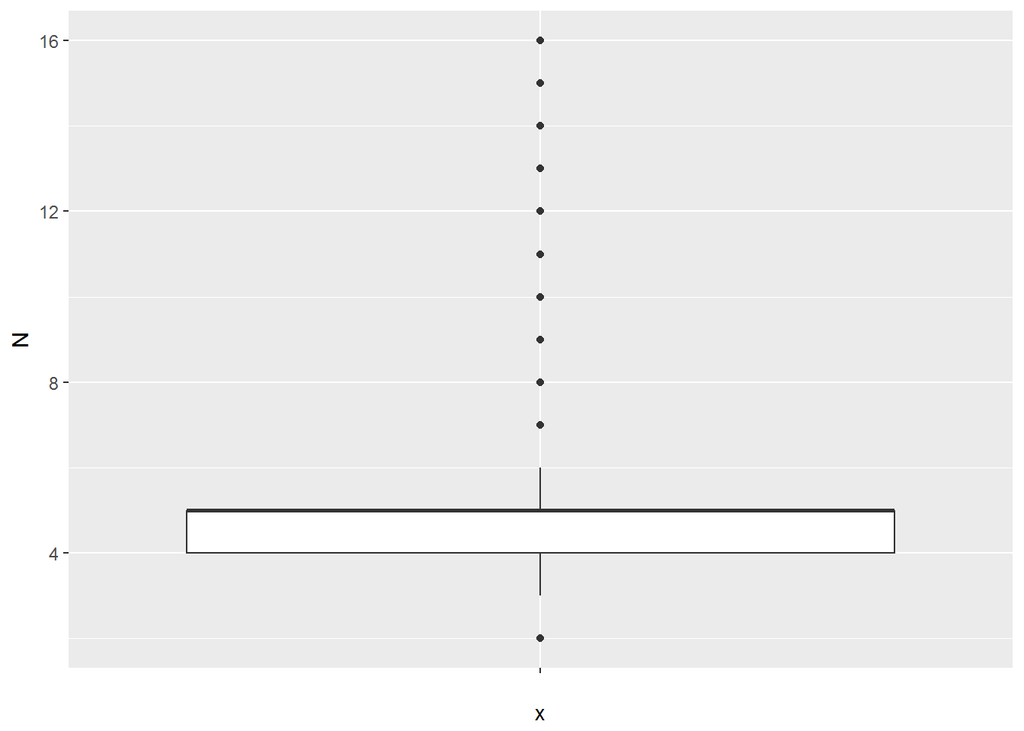

```r
# Nombre d'essieux
ggplot(varquanti,aes("", y = N)) + geom_boxplot()
```

la médiane du nombre d’essieux est 5. On observe des valeurs aberrantes car on considère qu’un nombre d’essieux supérieur à 8 est anormal.

```r
# Nombre de camions ayant plus de 8 essieux
siwim_data[N > 8, .N]
```

```
## [1] 2843
```

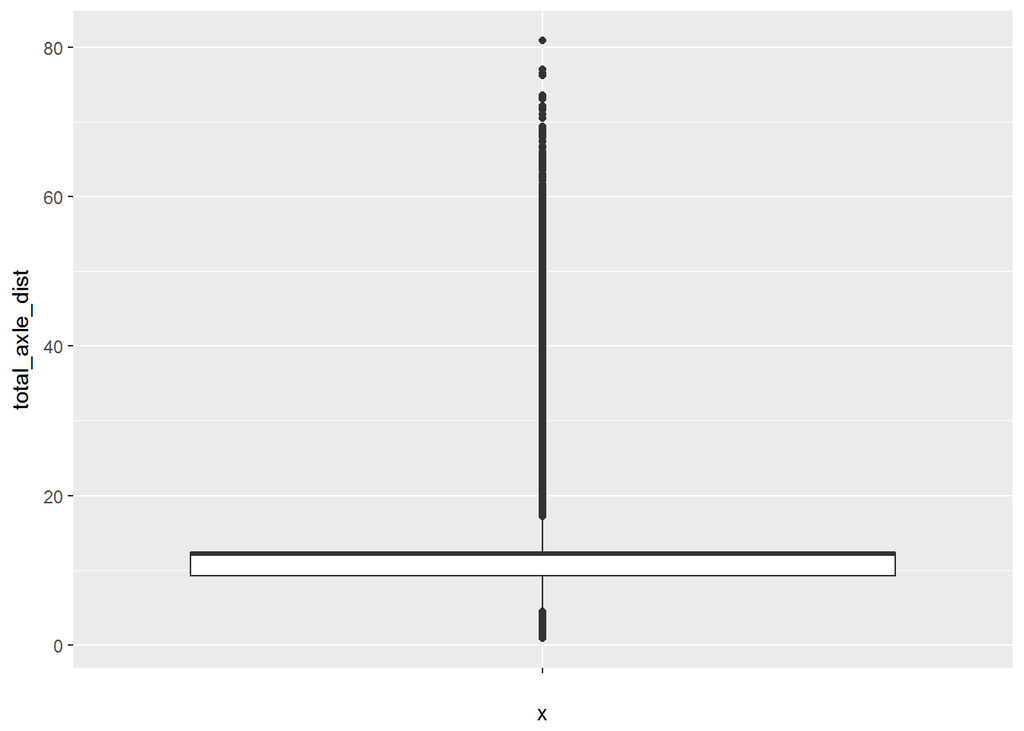

```r
# Distance totale entre les essieux les plus éloignés
ggplot(varquanti,aes("", y = total_axle_dist)) + geom_boxplot()
```

`Total_axle_dist` exprime la distance total entre les essieux les plus éloignés du camion. Elle donne une approximation de la taille (une taille minimale) du camion.

Nous constatons que de nombreuses valeur sont aberrantes car cette distance va jusqu’à 80 mètres :

```r
# Nombre de camions avec une distance totale entre essieux supérieure à 20 m
siwim_data[total_axle_dist > 20, .N]
```

```
## [1] 5102
```

En France, la longueur maximale autorisée est autour de 18.50 mètres, nous considérons donc qu’au-delà de 20 mètres la valeur est aberrante.

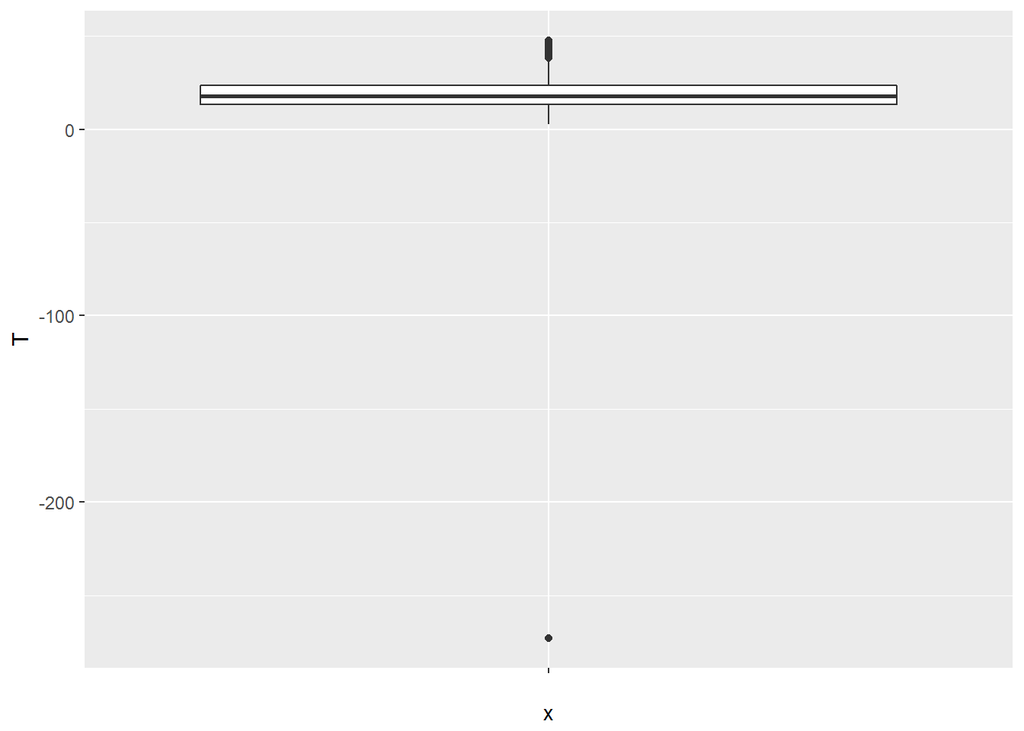

```r
# Temperature utilisée par la compensation
ggplot(varquanti,aes("", y = T)) + geom_boxplot()
```

```r
# Enregistrement de température inférieur à -20 degrés
siwim_data[T < -20, .N]
```

```
## [1] 2014
```

Nous constatons des valeurs clairement aberrantes, toutes situées à -273 degrés.

```r
varquanti[T == -273,.N]
```

```
## [1] 2014
```

Ces valeurs sont au nombre de 2014. Il faudra donc les traiter. L’observation des indices semblent montrer une continuité dans la captation de cette valeur aberrante.

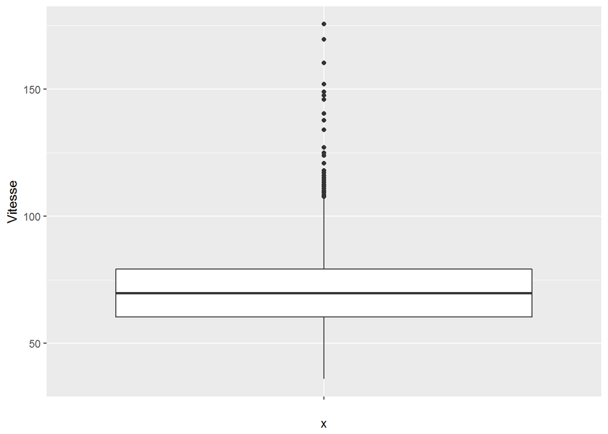

```r
# Vitesse
ggplot(varquanti,aes("", y = Vitesse)) + geom_boxplot()
```

La vitesse mediane est autour de 70km/h. Plusieurs vitesses apparaissent excessives (peut on rouler a plus de 130 km/h avec un camion ?).

```r
# Nombre de camions avec une vitesse supérieure à 130 km/h
siwim_data[Vitesse > 130, .N]
```

```
## [1] 19
```

Les derniers tracteurs de Volvo le peuvent. Mais nous pensons plutôt que ceux-ci ne fréquentent pas le pont de Normandie où la vitesse est de plus limitée à 90 km/h et que les camions chargés ont du mal à monter la pente. Nous devrons donc corriger ces valeurs aberrantes.

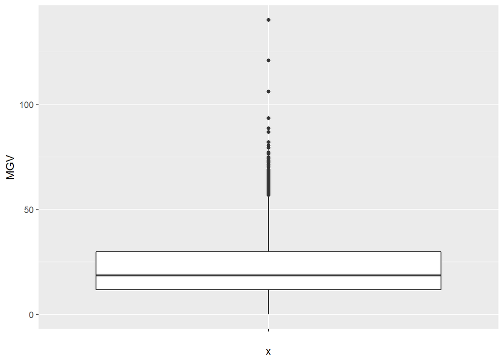

```r
# Masse du camion
ggplot(varquanti,aes("", y = MGV)) + geom_boxplot()
```

La Mediane du poids a 19 tonnes. Plusieurs valeurs semblent aberrantes (des camions de plus cent tonnes ou des camions avec un poids de 0 tonnes).

```r
# Camion avec un poids global supérieur à 70 tonnes
siwim_data[MGV > 70, .N]
```

```
## [1] 22
```

La limite légale étant à 44 tonnes et des poids lourds peuvent être surchargés, mais à partir de 70 tonnes il est sûr que les essieux ne tiennent pas la charge. Nous considérerons cette limite pour traiter les valeurs aberrantes.

De plus, il existent un nombre important de camions dont le poids est égal à 0 :

```r
# Nombre de camions avec un poids égal à 0
siwim_data[MGV == 0, .N]
```

```
## [1] 14316
```

Ces valeurs manquantes devront être traitées.

# Traitement des valeurs manquantes et aberrantes

Deux types de valeurs doivent être retraitées :

- les valeurs **manquantes**, qui doivent soit être estimées, soit éliminées par suppression de l’enregistrement associé
- les valeurs **aberrantes**, qui doivent soit être corrigées, soit éliminées par suppression de l’enregistrement associé

Nous allons explorer ces deux approches, en construisant deux jeux de données. Le premier avec des valeurs estimées, le deuxième avec des valeurs supprimées.

On travaille sur le tableau simplifié des variables quantitatives.

**Idée générale** : attribuer aux données aberrantes (dont nous sommes surs qu’elles soient fausses) un valeur “NA” puis reconstituer leur valeur grasse aux techniques d’imputation du package `"missMDA"`.

Les seuils sont fixés à partir de la connaissance métier.

```r
# On considere qu'une valeur supérieure à 8 essieux est aberrante
siwim_data[siwim_data$N > 8, N := NA]
siwim_data[is.na(siwim_data$N), Nb_axles := NA]
```

```r
# On considere comme valeur anormale une distance totale entre les axes > à 20 m
siwim_data[total_axle_dist > 20, total_axle_dist := NA]
```

```r
# On considere comme valeur anormale les températures négatives < à -10°C
siwim_data[T < -20, T := NA]
```

```r
# On considere comme valeur anormale la vitesse d'un camion > à 130 km/h
siwim_data[Vitesse > 130, Vitesse := NA]
```

```r
# On considere comme valeur anormale la masse d'un camion > à 70 T ou égale à 0
siwim_data[MGV > 70 | MGV == 0, MGV := NA]
```

On supprime des variables liées à un trop grand nombre d’axes :

```r
siwim_data [, c("A8", "A9","A10","A11","A12","A13","A14","A15","M9","M10",
                "M11","M12","M13","M14","M15","M16") := NULL]
```

On prépare le jeu de donnees `siwim_data_imput` contenant seulement les variables utiles pour l’imputation :

```r
siwim_data_imput <- siwim_data[, c( "Lane", "N", "Nb_axles", "Anomalie", "total_axle_dist", "T",
   "Reduced_chi_squared", "Time_num", "Vitesse", "MGV")]
```

L’imputation est réalisée par analyse factorielle des données multiples (FAMD) du package `Factominer`. Nous retenons l’information apportée par 7 axes factoriels :

```r
siwim_data_inputted <- imputeFAMD(siwim_data_imput, ncp = 7, method = "Regularized")
```

Voici le résumé des données après imputation :

```r
summary(siwim_data_inputted$completeObs)
```

```
##      Lane              N        Nb_axles   Anomalie   total_axle_dist
##  droite:167810   Min.   :2.00   2: 33262   N:130647   Min.   : 0.9032
##  gauche: 16118   1st Qu.:4.00   3: 11024   Y: 53281   1st Qu.: 9.2046
##                  Median :5.00   4: 28886              Median :12.1618
##                  Mean   :4.24   5:104079              Mean   :10.6736
##                  3rd Qu.:5.00   6:  3914              3rd Qu.:12.4314
##                  Max.   :8.00   7:  1981              Max.   :21.8551
##                                 8:   782
##        T          Reduced_chi_squared    Time_num         Vitesse
##  Min.   : 2.747   Min.   :    0.0     Min.   :0.5138   Min.   : 36.05
##  1st Qu.:13.752   1st Qu.:  100.0     1st Qu.:0.5929   1st Qu.: 60.43
##  Median :17.845   Median :  250.6     Median :0.6908   Median : 69.88
##  Mean   :19.237   Mean   :  475.5     Mean   :0.7071   Mean   : 70.12
##  3rd Qu.:23.713   3rd Qu.:  524.5     3rd Qu.:0.8274   3rd Qu.: 79.28
##  Max.   :47.568   Max.   :29201.3     Max.   :0.9078   Max.   :127.12
##
##       MGV
##  Min.   :-9.354
##  1st Qu.:13.533
##  Median :20.112
##  Mean   :21.316
##  3rd Qu.:30.120
##  Max.   :83.377
##
```

```r
# Transformation en data frame :
siwim_data_inputted <- as.data.frame(siwim_data_inputted$completeObs)
```

On concatène les variables imputées avec les colonnes initiales

```r
siwim_data_inputted_final <- cbind(siwim_data[, -c( "Lane","N", "Nb_axles", "Anomalie", "total_axle_dist", "T", "Reduced_chi_squared", "Time_num", "Vitesse", "MGV")],siwim_data_inputted)
```

Voici le résumé du jeu de données final après imputation, en comparaison de celui obtenu initialement :

```r
summary(siwim_data[,.( Lane,N, Nb_axles, Anomalie, total_axle_dist, T, Reduced_chi_squared, Time_num, Vitesse, MGV)])
```

```
##      Lane              N            Nb_axles      Anomalie
##  droite:167810   Min.   :2.000   5      :102466   N:130647
##  gauche: 16118   1st Qu.:4.000   2      : 32323   Y: 53281
##                  Median :5.000   4      : 28596
##                  Mean   :4.241   3      : 11023
##                  3rd Qu.:5.000   6      :  3914
##                  Max.   :8.000   (Other):  2763
##                  NA's   :2843    NA's   :  2843
##  total_axle_dist        T          Reduced_chi_squared    Time_num
##  Min.   : 0.903   Min.   : 2.747   Min.   :    0.0     Min.   :0.5138
##  1st Qu.: 9.188   1st Qu.:13.700   1st Qu.:  100.0     1st Qu.:0.5929
##  Median :12.165   Median :17.777   Median :  250.6     Median :0.6908
##  Mean   :10.622   Mean   :19.153   Mean   :  475.5     Mean   :0.7071
##  3rd Qu.:12.425   3rd Qu.:23.490   3rd Qu.:  524.5     3rd Qu.:0.8274
##  Max.   :20.000   Max.   :47.568   Max.   :29201.3     Max.   :0.9078
##  NA's   :5102     NA's   :2014
##     Vitesse            MGV
##  Min.   : 36.05   Min.   : 0.005
##  1st Qu.: 60.43   1st Qu.:13.487
##  Median : 69.88   Median :19.910
##  Mean   : 70.11   Mean   :21.382
##  3rd Qu.: 79.28   3rd Qu.:30.711
##  Max.   :127.12   Max.   :68.991
##  NA's   :19       NA's   :14338
```

```r
summary(siwim_data_inputted_final[,.( Lane,N, Nb_axles, Anomalie, total_axle_dist, T, Reduced_chi_squared, Time_num, Vitesse, MGV)])
```

```
##      Lane              N        Nb_axles   Anomalie   total_axle_dist
##  droite:167810   Min.   :2.00   2: 33262   N:130647   Min.   : 0.9032
##  gauche: 16118   1st Qu.:4.00   3: 11024   Y: 53281   1st Qu.: 9.2046
##                  Median :5.00   4: 28886              Median :12.1618
##                  Mean   :4.24   5:104079              Mean   :10.6736
##                  3rd Qu.:5.00   6:  3914              3rd Qu.:12.4314
##                  Max.   :8.00   7:  1981              Max.   :21.8551
##                                 8:   782
##        T          Reduced_chi_squared    Time_num         Vitesse
##  Min.   : 2.747   Min.   :    0.0     Min.   :0.5138   Min.   : 36.05
##  1st Qu.:13.752   1st Qu.:  100.0     1st Qu.:0.5929   1st Qu.: 60.43
##  Median :17.845   Median :  250.6     Median :0.6908   Median : 69.88
##  Mean   :19.237   Mean   :  475.5     Mean   :0.7071   Mean   : 70.12
##  3rd Qu.:23.713   3rd Qu.:  524.5     3rd Qu.:0.8274   3rd Qu.: 79.28
##  Max.   :47.568   Max.   :29201.3     Max.   :0.9078   Max.   :127.12
##
##       MGV
##  Min.   :-9.354
##  1st Qu.:13.533
##  Median :20.112
##  Mean   :21.316
##  3rd Qu.:30.120
##  Max.   :83.377
##
```

L’imputation semble donner de bons résultats. Etant basée sur une méthode d’estimation, les valeurs imputées peuvent de nouveaux franchir les limites fixées. Nous pouvons soit les supprimer, soit imputer aux valeurs limites de manière à conserver la donnée et donc le plus d’information possible.

```r
# Fixation aux valeurs limites pour les imputations qui auraient franchies les limites théoriques
siwim_data_inputted_final[N > 8, N := 8]
siwim_data_inputted_final[total_axle_dist > 20, total_axle_dist := 20]
siwim_data_inputted_final[T < -20, T := -10]
siwim_data_inputted_final[Vitesse > 130, Vitesse := 130]
siwim_data_inputted_final[MGV < 0, MGV := 0.5]
siwim_data_inputted_final[MGV > 70, MGV := 70]
```

La deuxième approche consiste à éliminer les individus ayant des valeurs manquantes et / ou aberrantes.

```r
## Suppression des individus comportant des donnees manquantes
siwim_data_missing_del <- siwim_data[!is.na(siwim_data$N)
                                            & !is.na(siwim_data$total_axle_dist)
                                            & !is.na(siwim_data$T)
                                            & !is.na(siwim_data$Vitesse)
                                            & !is.na(siwim_data$MGV)]
```

Résumé des données sans ces valeurs aberrantes :

```r
summary(siwim_data_missing_del[,.( Lane,N, Nb_axles, Anomalie, total_axle_dist, T, Reduced_chi_squared, Time_num, Vitesse, MGV)])
```

```
##      Lane              N            Nb_axles     Anomalie
##  droite:153040   Min.   :2.000   5      :97144   N:129225
##  gauche: 14227   1st Qu.:4.000   2      :30411   Y: 38042
##                  Median :5.000   4      :26895
##                  Mean   :4.203   3      : 9642
##                  3rd Qu.:5.000   6      : 2326
##                  Max.   :8.000   7      :  807
##                                  (Other):   42
##  total_axle_dist         T          Reduced_chi_squared    Time_num
##  Min.   : 0.9032   Min.   : 2.747   Min.   :    0.267   Min.   :0.5156
##  1st Qu.: 9.2015   1st Qu.:13.653   1st Qu.:   98.981   1st Qu.:0.5952
##  Median :12.1660   Median :17.705   Median :  243.367   Median :0.6929
##  Mean   :10.5977   Mean   :19.090   Mean   :  434.471   Mean   :0.7095
##  3rd Qu.:12.4160   3rd Qu.:23.400   3rd Qu.:  494.676   3rd Qu.:0.8288
##  Max.   :20.0000   Max.   :47.568   Max.   :15348.500   Max.   :0.9078
##
##     Vitesse            MGV
##  Min.   : 36.05   Min.   : 0.00965
##  1st Qu.: 60.43   1st Qu.:13.55673
##  Median : 69.55   Median :19.96891
##  Mean   : 69.88   Mean   :21.43055
##  3rd Qu.: 78.85   3rd Qu.:30.74939
##  Max.   :127.12   Max.   :68.49185
##
```

Nous constatons que les deux méthodes semblent aboutir à des résultats similaires : les résumés montrent que les valeur prises par les indicateurs de dispersion et de position restent semblables.

Nous stockons à présent nos trois jeux de données pour les prochaines analyses :

```r
write.csv(siwim_data, file = "2_Data/2_Retraitees/SiWIM_data_prepared.csv")

write.csv(siwim_data_inputted_final, file = "2_Data/2_Retraitees/SiWIM_data_after_input.csv")

write.csv(siwim_data_missing_del, file = "2_Data/2_Retraitees/SiWIM_data_missing_deleted.csv")
```